# Risk Factor Analysis

## Outcome Variable

**Outcome Variable:** stunted

## Predictor Variables

**Intervention Variable:** hhwealth_quart

**Adjustment Set:**

unadjusted

## Stratifying Variables

The analysis was stratified on these variable(s):

- agecat
- studyid

The following strata were considered:

- agecat: 12 months, studyid: ki0047075b-MAL-ED
- agecat: 12 months, studyid: ki1000108-CMC-V-BCS-2002
- agecat: 12 months, studyid: ki1000108-IRC
- agecat: 12 months, studyid: ki1017093b-PROVIDE
- agecat: 12 months, studyid: ki1066203-TanzaniaChild2
- agecat: 12 months, studyid: ki1113344-GMS-Nepal
- agecat: 12 months, studyid: ki1114097-CONTENT
- agecat: 12 months, studyid: ki1135781-COHORTS
- agecat: 12 months, studyid: ki1148112-LCNI-5
- agecat: 18 months, studyid: ki0047075b-MAL-ED
- agecat: 18 months, studyid: ki1000108-CMC-V-BCS-2002
- agecat: 18 months, studyid: ki1000108-IRC
- agecat: 18 months, studyid: ki1017093b-PROVIDE
- agecat: 18 months, studyid: ki1066203-TanzaniaChild2
- agecat: 18 months, studyid: ki1113344-GMS-Nepal
- agecat: 18 months, studyid: ki1114097-CONTENT
- agecat: 18 months, studyid: ki1135781-COHORTS
- agecat: 18 months, studyid: ki1148112-LCNI-5
- agecat: 24 months, studyid: ki0047075b-MAL-ED
- agecat: 24 months, studyid: ki1000108-CMC-V-BCS-2002
- agecat: 24 months, studyid: ki1000108-IRC
- agecat: 24 months, studyid: ki1017093b-PROVIDE
- agecat: 24 months, studyid: ki1066203-TanzaniaChild2
- agecat: 24 months, studyid: ki1113344-GMS-Nepal
- agecat: 24 months, studyid: ki1114097-CONTENT
- agecat: 24 months, studyid: ki1135781-COHORTS
- agecat: 24 months, studyid: ki1148112-LCNI-5
- agecat: 3 months, studyid: ki0047075b-MAL-ED
- agecat: 3 months, studyid: ki1000108-CMC-V-BCS-2002
- agecat: 3 months, studyid: ki1000108-IRC
- agecat: 3 months, studyid: ki1017093b-PROVIDE
- agecat: 3 months, studyid: ki1066203-TanzaniaChild2
- agecat: 3 months, studyid: ki1113344-GMS-Nepal
- agecat: 3 months, studyid: ki1114097-CONTENT
- agecat: 3 months, studyid: ki1135781-COHORTS
- agecat: 6 months, studyid: ki0047075b-MAL-ED
- agecat: 6 months, studyid: ki1000108-CMC-V-BCS-2002
- agecat: 6 months, studyid: ki1000108-IRC
- agecat: 6 months, studyid: ki1017093b-PROVIDE
- agecat: 6 months, studyid: ki1066203-TanzaniaChild2
- agecat: 6 months, studyid: ki1113344-GMS-Nepal
- agecat: 6 months, studyid: ki1114097-CONTENT
- agecat: 6 months, studyid: ki1135781-COHORTS
- agecat: 6 months, studyid: ki1148112-LCNI-5
- agecat: 9 months, studyid: ki0047075b-MAL-ED
- agecat: 9 months, studyid: ki1000108-CMC-V-BCS-2002
- agecat: 9 months, studyid: ki1000108-IRC
- agecat: 9 months, studyid: ki1017093b-PROVIDE
- agecat: 9 months, studyid: ki1066203-TanzaniaChild2
- agecat: 9 months, studyid: ki1113344-GMS-Nepal
- agecat: 9 months, studyid: ki1114097-CONTENT
- agecat: 9 months, studyid: ki1135781-COHORTS
- agecat: 9 months, studyid: ki1148112-LCNI-5
- agecat: Birth, studyid: ki0047075b-MAL-ED
- agecat: Birth, studyid: ki1000108-CMC-V-BCS-2002
- agecat: Birth, studyid: ki1000108-IRC
- agecat: Birth, studyid: ki1114097-CONTENT
- agecat: Birth, studyid: ki1135781-COHORTS

### Dropped Strata

Some strata were dropped due to rare outcomes:

- agecat: 12 months, studyid: ki1114097-CONTENT
- agecat: 18 months, studyid: ki1114097-CONTENT
- agecat: 24 months, studyid: ki1066203-TanzaniaChild2
- agecat: 24 months, studyid: ki1114097-CONTENT
- agecat: 3 months, studyid: ki1017093b-PROVIDE
- agecat: 3 months, studyid: ki1114097-CONTENT
- agecat: 6 months, studyid: ki1017093b-PROVIDE
- agecat: 6 months, studyid: ki1114097-CONTENT
- agecat: 9 months, studyid: ki1114097-CONTENT
- agecat: Birth, studyid: ki1000108-CMC-V-BCS-2002
- agecat: Birth, studyid: ki1114097-CONTENT

## Methods Detail

We’re interested in the causal parameters $E[Y_a]$ for all values of $a \in \mathcal{A}$. These parameters represent the mean outcome if, possibly contrary to fact, we intervened to set all units to have $A=a$. Under the randomization and positivity assumptions, these are identified by the statistical parameters $\psi_a=E_W[E_{Y|A,W}(Y|A=a,W)]$. In addition, we’re interested in the mean of $Y$, $E[Y]$ under no intervention (the observed mean). We will estimate these parameters by using SuperLearner to fit the relevant likelihood factors – $E_{Y|A,W}(Y|A=a,W)$ and $p(A=a|W)$, and then updating our likelihood fit using a joint TMLE.

For unadjusted analyses ($W=\{\}$), initial likelihoods were estimated using Lrnr_glm to estimate the simple $E(Y|A)$ and Lrnr_mean to estimate $p(A)$. For adjusted analyses, a small library containing Lrnr_glmnet, Lrnr_xgboost, and Lrnr_mean was used.

Having estimated these parameters, we will then use the delta method to estimate relative risks and attributable risks relative to a prespecified baseline level of $A$.

# Results Detail

## Results Plots

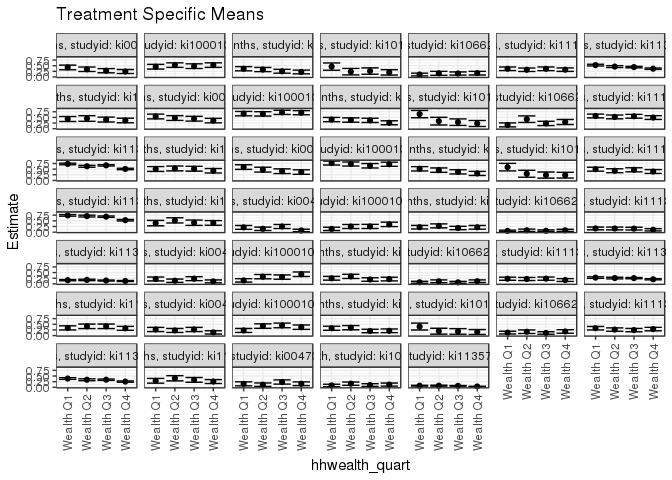

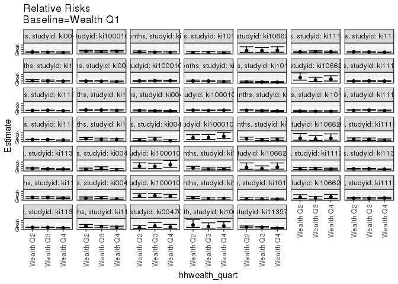

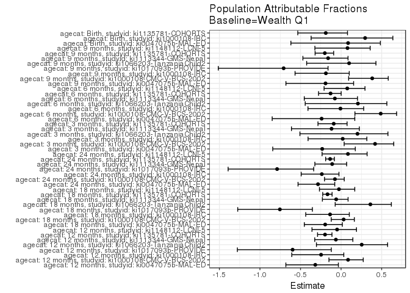

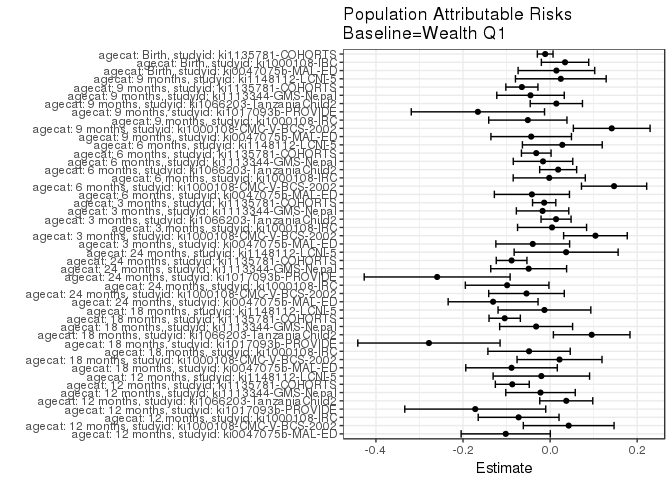

## Data Summary

| agecat | studyid | A | n | nA | nAY0 | nAY1 |
| --- | --- | --- | --- | --- | --- | --- |
| 12 months | ki0047075b-MAL-ED | Wealth Q1 | 359 | 90 | 52 | 38 |
| 12 months | ki0047075b-MAL-ED | Wealth Q2 | 359 | 88 | 58 | 30 |
| 12 months | ki0047075b-MAL-ED | Wealth Q3 | 359 | 90 | 65 | 25 |
| 12 months | ki0047075b-MAL-ED | Wealth Q4 | 359 | 91 | 69 | 22 |
| 12 months | ki1000108-CMC-V-BCS-2002 | Wealth Q1 | 368 | 88 | 48 | 40 |
| 12 months | ki1000108-CMC-V-BCS-2002 | Wealth Q2 | 368 | 95 | 45 | 50 |
| 12 months | ki1000108-CMC-V-BCS-2002 | Wealth Q3 | 368 | 90 | 47 | 43 |
| 12 months | ki1000108-CMC-V-BCS-2002 | Wealth Q4 | 368 | 95 | 45 | 50 |
| 12 months | ki1000108-IRC | Wealth Q1 | 406 | 104 | 66 | 38 |
| 12 months | ki1000108-IRC | Wealth Q2 | 406 | 100 | 67 | 33 |
| 12 months | ki1000108-IRC | Wealth Q3 | 406 | 103 | 77 | 26 |
| 12 months | ki1000108-IRC | Wealth Q4 | 406 | 99 | 77 | 22 |
| 12 months | ki1017093b-PROVIDE | Wealth Q1 | 153 | 37 | 20 | 17 |
| 12 months | ki1017093b-PROVIDE | Wealth Q2 | 153 | 34 | 26 | 8 |
| 12 months | ki1017093b-PROVIDE | Wealth Q3 | 153 | 38 | 28 | 10 |
| 12 months | ki1017093b-PROVIDE | Wealth Q4 | 153 | 44 | 35 | 9 |
| 12 months | ki1066203-TanzaniaChild2 | Wealth Q1 | 356 | 101 | 90 | 11 |
| 12 months | ki1066203-TanzaniaChild2 | Wealth Q2 | 356 | 68 | 57 | 11 |
| 12 months | ki1066203-TanzaniaChild2 | Wealth Q3 | 356 | 104 | 88 | 16 |
| 12 months | ki1066203-TanzaniaChild2 | Wealth Q4 | 356 | 83 | 69 | 14 |
| 12 months | ki1113344-GMS-Nepal | Wealth Q1 | 558 | 140 | 89 | 51 |
| 12 months | ki1113344-GMS-Nepal | Wealth Q2 | 558 | 141 | 96 | 45 |
| 12 months | ki1113344-GMS-Nepal | Wealth Q3 | 558 | 135 | 86 | 49 |
| 12 months | ki1113344-GMS-Nepal | Wealth Q4 | 558 | 142 | 96 | 46 |
| 12 months | ki1114097-CONTENT | Wealth Q1 | 215 | 59 | 48 | 11 |
| 12 months | ki1114097-CONTENT | Wealth Q2 | 215 | 52 | 46 | 6 |
| 12 months | ki1114097-CONTENT | Wealth Q3 | 215 | 52 | 46 | 6 |
| 12 months | ki1114097-CONTENT | Wealth Q4 | 215 | 52 | 49 | 3 |
| 12 months | ki1135781-COHORTS | Wealth Q1 | 3086 | 634 | 301 | 333 |
| 12 months | ki1135781-COHORTS | Wealth Q2 | 3086 | 556 | 300 | 256 |

[output cut: 222 more lines]

## Results Table

### Parameter: TSM

| agecat | studyid | intervention_level | baseline_level | estimate | ci_lower | ci_upper |
| --- | --- | --- | --- | --- | --- | --- |
| 12 months | ki0047075b-MAL-ED | Wealth Q1 | NA | 0.4222222 | 0.3200381 | 0.5244064 |
| 12 months | ki0047075b-MAL-ED | Wealth Q2 | NA | 0.3409091 | 0.2417336 | 0.4400846 |
| 12 months | ki0047075b-MAL-ED | Wealth Q3 | NA | 0.2777778 | 0.1851126 | 0.3704430 |
| 12 months | ki0047075b-MAL-ED | Wealth Q4 | NA | 0.2417582 | 0.1536680 | 0.3298484 |
| 12 months | ki1000108-CMC-V-BCS-2002 | Wealth Q1 | NA | 0.4545455 | 0.3503700 | 0.5587210 |
| 12 months | ki1000108-CMC-V-BCS-2002 | Wealth Q2 | NA | 0.5263158 | 0.4257744 | 0.6268572 |
| 12 months | ki1000108-CMC-V-BCS-2002 | Wealth Q3 | NA | 0.4777778 | 0.3744402 | 0.5811154 |
| 12 months | ki1000108-CMC-V-BCS-2002 | Wealth Q4 | NA | 0.5263158 | 0.4257744 | 0.6268572 |
| 12 months | ki1000108-IRC | Wealth Q1 | NA | 0.3653846 | 0.2727235 | 0.4580457 |
| 12 months | ki1000108-IRC | Wealth Q2 | NA | 0.3300000 | 0.2377263 | 0.4222737 |
| 12 months | ki1000108-IRC | Wealth Q3 | NA | 0.2524272 | 0.1684310 | 0.3364234 |
| 12 months | ki1000108-IRC | Wealth Q4 | NA | 0.2222222 | 0.1402272 | 0.3042172 |
| 12 months | ki1017093b-PROVIDE | Wealth Q1 | NA | 0.4594595 | 0.2983545 | 0.6205644 |
| 12 months | ki1017093b-PROVIDE | Wealth Q2 | NA | 0.2352941 | 0.0922450 | 0.3783433 |
| 12 months | ki1017093b-PROVIDE | Wealth Q3 | NA | 0.2631579 | 0.1226905 | 0.4036253 |
| 12 months | ki1017093b-PROVIDE | Wealth Q4 | NA | 0.2045455 | 0.0849683 | 0.3241226 |
| 12 months | ki1066203-TanzaniaChild2 | Wealth Q1 | NA | 0.1089109 | 0.0480702 | 0.1697516 |
| 12 months | ki1066203-TanzaniaChild2 | Wealth Q2 | NA | 0.1617647 | 0.0741193 | 0.2494101 |
| 12 months | ki1066203-TanzaniaChild2 | Wealth Q3 | NA | 0.1538462 | 0.0844061 | 0.2232862 |
| 12 months | ki1066203-TanzaniaChild2 | Wealth Q4 | NA | 0.1686747 | 0.0880013 | 0.2493481 |
| 12 months | ki1113344-GMS-Nepal | Wealth Q1 | NA | 0.3642857 | 0.2844999 | 0.4440715 |
| 12 months | ki1113344-GMS-Nepal | Wealth Q2 | NA | 0.3191489 | 0.2421383 | 0.3961596 |
| 12 months | ki1113344-GMS-Nepal | Wealth Q3 | NA | 0.3629630 | 0.2817764 | 0.4441495 |
| 12 months | ki1113344-GMS-Nepal | Wealth Q4 | NA | 0.3239437 | 0.2469031 | 0.4009843 |
| 12 months | ki1135781-COHORTS | Wealth Q1 | NA | 0.5252366 | 0.4863598 | 0.5641133 |
| 12 months | ki1135781-COHORTS | Wealth Q2 | NA | 0.4604317 | 0.4189948 | 0.5018685 |
| 12 months | ki1135781-COHORTS | Wealth Q3 | NA | 0.4373057 | 0.4060029 | 0.4686085 |
| 12 months | ki1135781-COHORTS | Wealth Q4 | NA | 0.3673469 | 0.3363753 | 0.3983186 |
| 12 months | ki1148112-LCNI-5 | Wealth Q1 | NA | 0.4285714 | 0.3178565 | 0.5392863 |
| 12 months | ki1148112-LCNI-5 | Wealth Q2 | NA | 0.4516129 | 0.3275363 | 0.5756895 |

[output cut: 158 more lines]

### Parameter: E(Y)

| agecat | studyid | intervention_level | baseline_level | estimate | ci_lower | ci_upper |
| --- | --- | --- | --- | --- | --- | --- |
| 12 months | ki0047075b-MAL-ED | NA | NA | 0.3203343 | 0.3132135 | 0.3274550 |
| 12 months | ki1000108-CMC-V-BCS-2002 | NA | NA | 0.4972826 | 0.4941044 | 0.5004608 |
| 12 months | ki1000108-IRC | NA | NA | 0.2931034 | 0.2874931 | 0.2987138 |
| 12 months | ki1017093b-PROVIDE | NA | NA | 0.2875817 | 0.2717778 | 0.3033856 |
| 12 months | ki1066203-TanzaniaChild2 | NA | NA | 0.1460674 | 0.1435717 | 0.1485631 |
| 12 months | ki1113344-GMS-Nepal | NA | NA | 0.3422939 | 0.3405406 | 0.3440473 |
| 12 months | ki1135781-COHORTS | NA | NA | 0.4384316 | 0.4364480 | 0.4404153 |
| 12 months | ki1148112-LCNI-5 | NA | NA | 0.4084967 | 0.4048431 | 0.4121503 |
| 18 months | ki0047075b-MAL-ED | NA | NA | 0.4517045 | 0.4448316 | 0.4585775 |
| 18 months | ki1000108-CMC-V-BCS-2002 | NA | NA | 0.6883469 | 0.6855236 | 0.6911701 |
| 18 months | ki1000108-IRC | NA | NA | 0.3555556 | 0.3502585 | 0.3608526 |
| 18 months | ki1017093b-PROVIDE | NA | NA | 0.3687943 | 0.3421339 | 0.3954547 |
| 18 months | ki1066203-TanzaniaChild2 | NA | NA | 0.2645914 | 0.2540405 | 0.2751424 |
| 18 months | ki1113344-GMS-Nepal | NA | NA | 0.5309091 | 0.5286434 | 0.5331747 |
| 18 months | ki1135781-COHORTS | NA | NA | 0.6237556 | 0.6207339 | 0.6267772 |
| 18 months | ki1148112-LCNI-5 | NA | NA | 0.4929178 | 0.4886643 | 0.4971714 |
| 24 months | ki0047075b-MAL-ED | NA | NA | 0.4600000 | 0.4510901 | 0.4689099 |
| 24 months | ki1000108-CMC-V-BCS-2002 | NA | NA | 0.7150538 | 0.7106902 | 0.7194173 |
| 24 months | ki1000108-IRC | NA | NA | 0.4156479 | 0.4081552 | 0.4231407 |
| 24 months | ki1017093b-PROVIDE | NA | NA | 0.3288591 | 0.3058129 | 0.3519053 |
| 24 months | ki1113344-GMS-Nepal | NA | NA | 0.4468938 | 0.4434314 | 0.4503561 |
| 24 months | ki1135781-COHORTS | NA | NA | 0.6536370 | 0.6505650 | 0.6567089 |
| 24 months | ki1148112-LCNI-5 | NA | NA | 0.4368601 | 0.4312880 | 0.4424322 |
| 3 months | ki0047075b-MAL-ED | NA | NA | 0.1712707 | 0.1644226 | 0.1781189 |
| 3 months | ki1000108-CMC-V-BCS-2002 | NA | NA | 0.2486188 | 0.2412923 | 0.2559453 |
| 3 months | ki1000108-IRC | NA | NA | 0.2235872 | 0.2203210 | 0.2268534 |
| 3 months | ki1066203-TanzaniaChild2 | NA | NA | 0.0679443 | 0.0669345 | 0.0689540 |
| 3 months | ki1113344-GMS-Nepal | NA | NA | 0.1471103 | 0.1451355 | 0.1490851 |
| 3 months | ki1135781-COHORTS | NA | NA | 0.1496844 | 0.1490804 | 0.1502884 |
| 6 months | ki0047075b-MAL-ED | NA | NA | 0.1741573 | 0.1688577 | 0.1794569 |
| 6 months | ki1000108-CMC-V-BCS-2002 | NA | NA | 0.3008130 | 0.2909205 | 0.3107056 |
| 6 months | ki1000108-IRC | NA | NA | 0.2457002 | 0.2406523 | 0.2507482 |
| 6 months | ki1066203-TanzaniaChild2 | NA | NA | 0.0894632 | 0.0874638 | 0.0914627 |
| 6 months | ki1113344-GMS-Nepal | NA | NA | 0.2113677 | 0.2093425 | 0.2133928 |
| 6 months | ki1135781-COHORTS | NA | NA | 0.2449174 | 0.2439537 | 0.2458811 |
| 6 months | ki1148112-LCNI-5 | NA | NA | 0.3679012 | 0.3639398 | 0.3718626 |
| 9 months | ki0047075b-MAL-ED | NA | NA | 0.2262570 | 0.2207762 | 0.2317378 |
| 9 months | ki1000108-CMC-V-BCS-2002 | NA | NA | 0.3688525 | 0.3602026 | 0.3775023 |
| 9 months | ki1000108-IRC | NA | NA | 0.2727273 | 0.2663985 | 0.2790560 |
| 9 months | ki1017093b-PROVIDE | NA | NA | 0.2341772 | 0.2189379 | 0.2494166 |
| 9 months | ki1066203-TanzaniaChild2 | NA | NA | 0.1454965 | 0.1429044 | 0.1480887 |
| 9 months | ki1113344-GMS-Nepal | NA | NA | 0.2813067 | 0.2787348 | 0.2838786 |
| 9 months | ki1135781-COHORTS | NA | NA | 0.3230525 | 0.3213455 | 0.3247595 |
| 9 months | ki1148112-LCNI-5 | NA | NA | 0.3123028 | 0.3063491 | 0.3182566 |
| Birth | ki0047075b-MAL-ED | NA | NA | 0.1683849 | 0.1633060 | 0.1734637 |
| Birth | ki1000108-IRC | NA | NA | 0.1159794 | 0.1129891 | 0.1189697 |
| Birth | ki1135781-COHORTS | NA | NA | 0.0594752 | 0.0589769 | 0.0599735 |

### Parameter: RR

| agecat | studyid | intervention_level | baseline_level | estimate | ci_lower | ci_upper |
| --- | --- | --- | --- | --- | --- | --- |
| 12 months | ki0047075b-MAL-ED | Wealth Q2 | Wealth Q1 | 0.8074163 | 0.5530332 | 1.1788100 |
| 12 months | ki0047075b-MAL-ED | Wealth Q3 | Wealth Q1 | 0.6578947 | 0.4356800 | 0.9934480 |
| 12 months | ki0047075b-MAL-ED | Wealth Q4 | Wealth Q1 | 0.5725853 | 0.3697173 | 0.8867694 |
| 12 months | ki1000108-CMC-V-BCS-2002 | Wealth Q2 | Wealth Q1 | 1.1578947 | 0.8591982 | 1.5604319 |
| 12 months | ki1000108-CMC-V-BCS-2002 | Wealth Q3 | Wealth Q1 | 1.0511111 | 0.7669897 | 1.4404817 |
| 12 months | ki1000108-CMC-V-BCS-2002 | Wealth Q4 | Wealth Q1 | 1.1578947 | 0.8591982 | 1.5604319 |
| 12 months | ki1000108-IRC | Wealth Q2 | Wealth Q1 | 0.9031579 | 0.6191875 | 1.3173622 |
| 12 months | ki1000108-IRC | Wealth Q3 | Wealth Q1 | 0.6908533 | 0.4546612 | 1.0497451 |
| 12 months | ki1000108-IRC | Wealth Q4 | Wealth Q1 | 0.6081871 | 0.3886809 | 0.9516589 |
| 12 months | ki1017093b-PROVIDE | Wealth Q2 | Wealth Q1 | 0.5121107 | 0.2538422 | 1.0331513 |
| 12 months | ki1017093b-PROVIDE | Wealth Q3 | Wealth Q1 | 0.5727554 | 0.3024195 | 1.0847473 |
| 12 months | ki1017093b-PROVIDE | Wealth Q4 | Wealth Q1 | 0.4451872 | 0.2251579 | 0.8802339 |
| 12 months | ki1066203-TanzaniaChild2 | Wealth Q2 | Wealth Q1 | 1.4852941 | 0.6820827 | 3.2343564 |
| 12 months | ki1066203-TanzaniaChild2 | Wealth Q3 | Wealth Q1 | 1.4125874 | 0.6888280 | 2.8968091 |
| 12 months | ki1066203-TanzaniaChild2 | Wealth Q4 | Wealth Q1 | 1.5487404 | 0.7423312 | 3.2311680 |
| 12 months | ki1113344-GMS-Nepal | Wealth Q2 | Wealth Q1 | 0.8760951 | 0.6324482 | 1.2136056 |
| 12 months | ki1113344-GMS-Nepal | Wealth Q3 | Wealth Q1 | 0.9963689 | 0.7285572 | 1.3626261 |
| 12 months | ki1113344-GMS-Nepal | Wealth Q4 | Wealth Q1 | 0.8892571 | 0.6436002 | 1.2286793 |
| 12 months | ki1135781-COHORTS | Wealth Q2 | Wealth Q1 | 0.8766176 | 0.7801974 | 0.9849539 |
| 12 months | ki1135781-COHORTS | Wealth Q3 | Wealth Q1 | 0.8325880 | 0.7511240 | 0.9228874 |
| 12 months | ki1135781-COHORTS | Wealth Q4 | Wealth Q1 | 0.6993933 | 0.6251684 | 0.7824307 |
| 12 months | ki1148112-LCNI-5 | Wealth Q2 | Wealth Q1 | 1.0537634 | 0.7227066 | 1.5364706 |
| 12 months | ki1148112-LCNI-5 | Wealth Q3 | Wealth Q1 | 0.9451477 | 0.6515358 | 1.3710745 |
| 12 months | ki1148112-LCNI-5 | Wealth Q4 | Wealth Q1 | 0.8484848 | 0.5810267 | 1.2390593 |
| 18 months | ki0047075b-MAL-ED | Wealth Q2 | Wealth Q1 | 0.8723404 | 0.6491100 | 1.1723403 |
| 18 months | ki0047075b-MAL-ED | Wealth Q3 | Wealth Q1 | 0.8179119 | 0.6016776 | 1.1118577 |
| 18 months | ki0047075b-MAL-ED | Wealth Q4 | Wealth Q1 | 0.6639685 | 0.4747311 | 0.9286400 |
| 18 months | ki1000108-CMC-V-BCS-2002 | Wealth Q2 | Wealth Q1 | 0.9838710 | 0.7993703 | 1.2109558 |
| 18 months | ki1000108-CMC-V-BCS-2002 | Wealth Q3 | Wealth Q1 | 1.0833333 | 0.8917806 | 1.3160312 |
| 18 months | ki1000108-CMC-V-BCS-2002 | Wealth Q4 | Wealth Q1 | 1.0625000 | 0.8744950 | 1.2909236 |

[output cut: 111 more lines]

### Parameter: PAR

| agecat | studyid | intervention_level | baseline_level | estimate | ci_lower | ci_upper |
| --- | --- | --- | --- | --- | --- | --- |
| 12 months | ki0047075b-MAL-ED | Wealth Q1 | NA | -0.1018880 | -0.2043199 | 0.0005440 |
| 12 months | ki1000108-CMC-V-BCS-2002 | Wealth Q1 | NA | 0.0427372 | -0.0614868 | 0.1469611 |
| 12 months | ki1000108-IRC | Wealth Q1 | NA | -0.0722812 | -0.1651119 | 0.0205496 |
| 12 months | ki1017093b-PROVIDE | Wealth Q1 | NA | -0.1718778 | -0.3337560 | -0.0099995 |
| 12 months | ki1066203-TanzaniaChild2 | Wealth Q1 | NA | 0.0371565 | -0.0237354 | 0.0980484 |
| 12 months | ki1113344-GMS-Nepal | Wealth Q1 | NA | -0.0219918 | -0.1017969 | 0.0578133 |
| 12 months | ki1135781-COHORTS | Wealth Q1 | NA | -0.0868050 | -0.1257323 | -0.0478776 |
| 12 months | ki1148112-LCNI-5 | Wealth Q1 | NA | -0.0200747 | -0.1308499 | 0.0907005 |
| 18 months | ki0047075b-MAL-ED | Wealth Q1 | NA | -0.0885253 | -0.1936238 | 0.0165732 |
| 18 months | ki1000108-CMC-V-BCS-2002 | Wealth Q1 | NA | 0.0216802 | -0.0758843 | 0.1192447 |
| 18 months | ki1000108-IRC | Wealth Q1 | NA | -0.0482906 | -0.1428572 | 0.0462760 |
| 18 months | ki1017093b-PROVIDE | Wealth Q1 | NA | -0.2782645 | -0.4416587 | -0.1148703 |
| 18 months | ki1066203-TanzaniaChild2 | Wealth Q1 | NA | 0.0955774 | 0.0076003 | 0.1835545 |
| 18 months | ki1113344-GMS-Nepal | Wealth Q1 | NA | -0.0320539 | -0.1158327 | 0.0517250 |
| 18 months | ki1135781-COHORTS | Wealth Q1 | NA | -0.1042850 | -0.1402623 | -0.0683076 |
| 18 months | ki1148112-LCNI-5 | Wealth Q1 | NA | -0.0129645 | -0.1194869 | 0.0935579 |
| 24 months | ki0047075b-MAL-ED | Wealth Q1 | NA | -0.1309091 | -0.2341665 | -0.0276517 |
| 24 months | ki1000108-CMC-V-BCS-2002 | Wealth Q1 | NA | -0.0541770 | -0.1409688 | 0.0326148 |
| 24 months | ki1000108-IRC | Wealth Q1 | NA | -0.0986378 | -0.1946451 | -0.0026305 |
| 24 months | ki1017093b-PROVIDE | Wealth Q1 | NA | -0.2593762 | -0.4269543 | -0.0917981 |
| 24 months | ki1113344-GMS-Nepal | Wealth Q1 | NA | -0.0491692 | -0.1362819 | 0.0379435 |
| 24 months | ki1135781-COHORTS | Wealth Q1 | NA | -0.0884066 | -0.1236420 | -0.0531711 |
| 24 months | ki1148112-LCNI-5 | Wealth Q1 | NA | 0.0368601 | -0.0825697 | 0.1562898 |
| 3 months | ki0047075b-MAL-ED | Wealth Q1 | NA | -0.0398404 | -0.1245465 | 0.0448658 |
| 3 months | ki1000108-CMC-V-BCS-2002 | Wealth Q1 | NA | 0.1041743 | 0.0310782 | 0.1772705 |
| 3 months | ki1000108-IRC | Wealth Q1 | NA | 0.0045396 | -0.0747357 | 0.0838149 |
| 3 months | ki1066203-TanzaniaChild2 | Wealth Q1 | NA | 0.0137274 | -0.0207649 | 0.0482197 |
| 3 months | ki1113344-GMS-Nepal | Wealth Q1 | NA | -0.0172732 | -0.0774763 | 0.0429299 |
| 3 months | ki1135781-COHORTS | Wealth Q1 | NA | -0.0135809 | -0.0403123 | 0.0131505 |
| 6 months | ki0047075b-MAL-ED | Wealth Q1 | NA | -0.0417518 | -0.1280015 | 0.0444979 |
| 6 months | ki1000108-CMC-V-BCS-2002 | Wealth Q1 | NA | 0.1469669 | 0.0720797 | 0.2218540 |
| 6 months | ki1000108-IRC | Wealth Q1 | NA | -0.0019188 | -0.0847334 | 0.0808958 |
| 6 months | ki1066203-TanzaniaChild2 | Wealth Q1 | NA | 0.0185412 | -0.0239177 | 0.0610002 |
| 6 months | ki1113344-GMS-Nepal | Wealth Q1 | NA | -0.0162185 | -0.0845529 | 0.0521158 |
| 6 months | ki1135781-COHORTS | Wealth Q1 | NA | -0.0317743 | -0.0657948 | 0.0022462 |
| 6 months | ki1148112-LCNI-5 | Wealth Q1 | NA | 0.0280954 | -0.0635738 | 0.1197646 |
| 9 months | ki0047075b-MAL-ED | Wealth Q1 | NA | -0.0434059 | -0.1358963 | 0.0490845 |
| 9 months | ki1000108-CMC-V-BCS-2002 | Wealth Q1 | NA | 0.1415797 | 0.0534767 | 0.2296828 |
| 9 months | ki1000108-IRC | Wealth Q1 | NA | -0.0510823 | -0.1409176 | 0.0387531 |
| 9 months | ki1017093b-PROVIDE | Wealth Q1 | NA | -0.1658228 | -0.3188842 | -0.0127614 |
| 9 months | ki1066203-TanzaniaChild2 | Wealth Q1 | NA | 0.0143490 | -0.0456755 | 0.0743735 |
| 9 months | ki1113344-GMS-Nepal | Wealth Q1 | NA | -0.0449344 | -0.1224330 | 0.0325642 |
| 9 months | ki1135781-COHORTS | Wealth Q1 | NA | -0.0647633 | -0.1016211 | -0.0279055 |
| 9 months | ki1148112-LCNI-5 | Wealth Q1 | NA | 0.0246316 | -0.0795453 | 0.1288086 |
| Birth | ki0047075b-MAL-ED | Wealth Q1 | NA | 0.0145387 | -0.0734711 | 0.1025486 |
| Birth | ki1000108-IRC | Wealth Q1 | NA | 0.0343467 | -0.0200150 | 0.0887085 |
| Birth | ki1135781-COHORTS | Wealth Q1 | NA | -0.0112189 | -0.0292390 | 0.0068013 |

### Parameter: PAF

| agecat | studyid | intervention_level | baseline_level | estimate | ci_lower | ci_upper |
| --- | --- | --- | --- | --- | --- | --- |
| 12 months | ki0047075b-MAL-ED | Wealth Q1 | NA | -0.3180676 | -0.6806835 | -0.0336880 |
| 12 months | ki1000108-CMC-V-BCS-2002 | Wealth Q1 | NA | 0.0859414 | -0.1496006 | 0.2732231 |
| 12 months | ki1000108-IRC | Wealth Q1 | NA | -0.2466063 | -0.6076042 | 0.0333272 |
| 12 months | ki1017093b-PROVIDE | Wealth Q1 | NA | -0.5976658 | -1.2783789 | -0.1203300 |
| 12 months | ki1066203-TanzaniaChild2 | Wealth Q1 | NA | 0.2543793 | -0.3038893 | 0.5736216 |
| 12 months | ki1113344-GMS-Nepal | Wealth Q1 | NA | -0.0642483 | -0.3249152 | 0.1451344 |
| 12 months | ki1135781-COHORTS | Wealth Q1 | NA | -0.1979897 | -0.2902044 | -0.1123659 |
| 12 months | ki1148112-LCNI-5 | Wealth Q1 | NA | -0.0491429 | -0.3586113 | 0.1898340 |
| 18 months | ki0047075b-MAL-ED | Wealth Q1 | NA | -0.1959806 | -0.4530858 | 0.0156330 |
| 18 months | ki1000108-CMC-V-BCS-2002 | Wealth Q1 | NA | 0.0314961 | -0.1211335 | 0.1633468 |
| 18 months | ki1000108-IRC | Wealth Q1 | NA | -0.1358173 | -0.4356589 | 0.1014015 |
| 18 months | ki1017093b-PROVIDE | Wealth Q1 | NA | -0.7545249 | -1.2741552 | -0.3536269 |
| 18 months | ki1066203-TanzaniaChild2 | Wealth Q1 | NA | 0.3612262 | -0.0726215 | 0.6195937 |
| 18 months | ki1113344-GMS-Nepal | Wealth Q1 | NA | -0.0603754 | -0.2305331 | 0.0862528 |
| 18 months | ki1135781-COHORTS | Wealth Q1 | NA | -0.1671888 | -0.2263937 | -0.1108421 |
| 18 months | ki1148112-LCNI-5 | Wealth Q1 | NA | -0.0263016 | -0.2668559 | 0.1685756 |
| 24 months | ki0047075b-MAL-ED | Wealth Q1 | NA | -0.2845850 | -0.5305106 | -0.0781752 |
| 24 months | ki1000108-CMC-V-BCS-2002 | Wealth Q1 | NA | -0.0757663 | -0.2042838 | 0.0390362 |
| 24 months | ki1000108-IRC | Wealth Q1 | NA | -0.2373109 | -0.4917097 | -0.0262978 |
| 24 months | ki1017093b-PROVIDE | Wealth Q1 | NA | -0.7887155 | -1.3922771 | -0.3374300 |
| 24 months | ki1113344-GMS-Nepal | Wealth Q1 | NA | -0.1100244 | -0.3231594 | 0.0687788 |
| 24 months | ki1135781-COHORTS | Wealth Q1 | NA | -0.1352533 | -0.1905224 | -0.0825501 |
| 24 months | ki1148112-LCNI-5 | Wealth Q1 | NA | 0.0843750 | -0.2341390 | 0.3206850 |
| 3 months | ki0047075b-MAL-ED | Wealth Q1 | NA | -0.2326165 | -0.8423818 | 0.1753374 |
| 3 months | ki1000108-CMC-V-BCS-2002 | Wealth Q1 | NA | 0.4190123 | 0.0379243 | 0.6491475 |
| 3 months | ki1000108-IRC | Wealth Q1 | NA | 0.0203035 | -0.4068939 | 0.3177842 |
| 3 months | ki1066203-TanzaniaChild2 | Wealth Q1 | NA | 0.2020389 | -0.5074152 | 0.5775936 |
| 3 months | ki1113344-GMS-Nepal | Wealth Q1 | NA | -0.1174168 | -0.6117234 | 0.2252887 |
| 3 months | ki1135781-COHORTS | Wealth Q1 | NA | -0.0907303 | -0.2847769 | 0.0740085 |
| 6 months | ki0047075b-MAL-ED | Wealth Q1 | NA | -0.2397361 | -0.8492415 | 0.1688779 |
| 6 months | ki1000108-CMC-V-BCS-2002 | Wealth Q1 | NA | 0.4885655 | 0.1704862 | 0.6846764 |
| 6 months | ki1000108-IRC | Wealth Q1 | NA | -0.0078095 | -0.4080876 | 0.2786812 |
| 6 months | ki1066203-TanzaniaChild2 | Wealth Q1 | NA | 0.2072498 | -0.4422111 | 0.5642435 |
| 6 months | ki1113344-GMS-Nepal | Wealth Q1 | NA | -0.0767314 | -0.4538393 | 0.2025594 |
| 6 months | ki1135781-COHORTS | Wealth Q1 | NA | -0.1297348 | -0.2775587 | 0.0009846 |
| 6 months | ki1148112-LCNI-5 | Wealth Q1 | NA | 0.0763667 | -0.2096030 | 0.2947286 |
| 9 months | ki0047075b-MAL-ED | Wealth Q1 | NA | -0.1918435 | -0.6799090 | 0.1544239 |
| 9 months | ki1000108-CMC-V-BCS-2002 | Wealth Q1 | NA | 0.3838384 | 0.0931274 | 0.5813578 |
| 9 months | ki1000108-IRC | Wealth Q1 | NA | -0.1873016 | -0.5673680 | 0.1006037 |
| 9 months | ki1017093b-PROVIDE | Wealth Q1 | NA | -0.7081081 | -1.5134588 | -0.1608041 |
| 9 months | ki1066203-TanzaniaChild2 | Wealth Q1 | NA | 0.0986209 | -0.4244384 | 0.4296107 |
| 9 months | ki1113344-GMS-Nepal | Wealth Q1 | NA | -0.1597346 | -0.4707705 | 0.0855239 |
| 9 months | ki1135781-COHORTS | Wealth Q1 | NA | -0.2004730 | -0.3202222 | -0.0915854 |
| 9 months | ki1148112-LCNI-5 | Wealth Q1 | NA | 0.0788709 | -0.3229898 | 0.3586657 |
| Birth | ki0047075b-MAL-ED | Wealth Q1 | NA | 0.0863422 | -0.6186741 | 0.4842875 |
| Birth | ki1000108-IRC | Wealth Q1 | NA | 0.2961451 | -0.3692185 | 0.6381792 |
| Birth | ki1135781-COHORTS | Wealth Q1 | NA | -0.1886310 | -0.5337961 | 0.0788583 |